# proj2-Chen

Weixuan Chen

3/24/2023

## Data

```r
d1=read.csv(file="http://faraway.neu.edu/biostats/assn2_dataset1.csv", as.is = FALSE)
d2=read.csv(file="http://faraway.neu.edu/biostats/assn2_dataset3.csv")
```

```r
d1
```

```
##       sitenum      lat       lon year                       speciesName
## 1          18 43.30000 -124.4000 1999                        Mitra idae
## 2          17 43.31000 -124.3933 1999                        Mitra idae
## 3          16 43.33000 -124.3740 1999                        Mitra idae
## 4          19 41.06000 -124.1500 1999                        Mitra idae
## 5          15 44.20000 -124.1100 1999                        Mitra idae
## 6          14 44.21833 -124.1100 1999                        Mitra idae
## 7          13 44.24250 -124.1100 1999                        Mitra idae
## 8          20 40.02000 -124.0733 1999                        Mitra idae
## 9          12 44.74667 -124.0600 1999                        Mitra idae
## 10         11 44.80667 -124.0600 1999                        Mitra idae
## 11         10 44.82667 -124.0567 1999                        Mitra idae
## 12          8 45.93000 -123.9867 1999                        Mitra idae
## 13          7 45.94000 -123.9867 1999                        Mitra idae
## 14          9 45.77000 -123.9700 1999                        Mitra idae
```

[output cut: 24986 more lines]

## Problem 1

## 1

```r
 # Fill in this code wherever there is an XXXX
d1.y2000=subset(d1, year == 2000) # Extract data from years 2000
d1.y2003=subset(d1, year == 2003) # Extract data from years 2003
```

```r
# Find unique species IDs
unique.species=unique(d1$speciesID)
# Initialize matrix to hold weighted means
mean.mat <- matrix(nrow= length(unique.species), ncol= 2, NA)
# Compute the weighted mean of each species
for (i in 1:length(unique.species)) {
  tmp1=subset(d1.y2000, speciesID == unique.species[i])
  tmp2=subset(d1.y2003, speciesID == unique.species[i])
  mean.mat[i,]=c(weighted.mean(tmp1$lat , tmp1$abundance ), weighted.mean(tmp2$lat , tmp2$abundance ))
}
#Create a matrix holding the change in weighted mean latitude, along with another variable for species
mean.change <- data.frame(speciesID=unique.species,
                      moveDist= mean.mat[,1] - mean.mat[,2])
```

```r
head(mean.change)
```

```
##   speciesID   moveDist
## 1       479        NaN
## 2       361 -10.572604
## 3       159   7.150244
## 4        79  -2.574906
## 5       357  -4.428831
## 6       478        NaN
```

## 2

```r
## Create a new column
mean.change["moved.north"] = NA
## Determine if moveDist is greater than 0 and assign the direction
for (i in 1:length(mean.change$speciesID)){
  ifelse(mean.change$moveDist[i] > 0, mean.change$moved.north[i] <- TRUE, mean.change$moved.north[i] <- FALSE)
}

head(mean.change)
```

```
##   speciesID   moveDist moved.north
## 1       479        NaN          NA
## 2       361 -10.572604       FALSE
## 3       159   7.150244        TRUE
## 4        79  -2.574906       FALSE
## 5       357  -4.428831       FALSE
## 6       478        NaN          NA
```

## 3

```r
# Count the number of species moving northward
nrow(subset(mean.change, mean.change$moved.north == TRUE))
```

```
## [1] 31
```

```r
# Count the number of species moving southward
nrow(subset(mean.change, mean.change$moved.north == FALSE))
```

```
## [1] 26
```

## 4

We use one-sample t-test to test if the mean of moveDist is 0 H0: mean of moveDist = 0 H1: mean of moveDist ${\neq}$ 0

```r
t.test(mean.change$moveDist, mu = 0, alternative = "two.sided")
```

```
##
##  One Sample t-test
##
## data:  mean.change$moveDist
## t = 0.51573, df = 56, p-value = 0.6081
## alternative hypothesis: true mean is not equal to 0
## 95 percent confidence interval:
##  -0.7229387  1.2242289
## sample estimates:
## mean of x
## 0.2506451
```

We have p-value 0.6, which we cannot reject the null hypothesis in any level of the significance. Therefore, we do not have enough evidence to show the species has the tendency to move northward or southward.

## Problem 2

## 1

```r
dispersal.mat <- matrix(nrow= length(unique.species), ncol= 2, NA)
## Using for loop to match the dispersal type with each species
for (i in 1:length(unique.species)) {
  disp=subset(d1, speciesID == unique.species[i])
  # Assign the name of dispersal to each species
  dispersal.mat[i,]=c(unique.species[i], as.character(disp$development[1]))
}

dispersal.df <- data.frame(speciesID=unique.species,
                      dispersal= dispersal.mat[,2])
## Order the species ID
dispersal.df <- dispersal.df[order(dispersal.df$speciesID,decreasing = FALSE), ]

dispersal.df
```

```
##    speciesID    dispersal
## 19         1     Nonplank
## 61         2 Planknonfeed
## 50         8 Planknonfeed
## 69        10 Planknonfeed
## 32        11    Plankfeed
## 20        13     Nonplank
## 49        17 Planknonfeed
## 41        18    Plankfeed
## 46        20    Plankfeed
## 65        29 Planknonfeed
## 51        34 Planknonfeed
## 17        40     Nonplank
## 37        50    Plankfeed
## 39        51    Plankfeed
```

[output cut: 55 more lines]

## 2

```r
disp <- merge(mean.change, dispersal.df, by = "speciesID")
# Remove NA values. The complete.cases function tells you if a row has complete entries (no NAs)
disp <- disp[complete.cases(disp$moveDist), ]
disp
```

```
##    speciesID     moveDist moved.north    dispersal
## 1          1  -0.57246968       FALSE     Nonplank
## 2          2  -1.96589961       FALSE Planknonfeed
## 3          8   0.77073246        TRUE Planknonfeed
## 4         10  -1.20418482       FALSE Planknonfeed
## 5         11  -2.84055905       FALSE    Plankfeed
## 6         13   0.79959491        TRUE     Nonplank
## 7         17   4.95970459        TRUE Planknonfeed
## 8         18  -0.07608653       FALSE    Plankfeed
## 9         20   3.02404280        TRUE    Plankfeed
## 10        29   4.27784449        TRUE Planknonfeed
## 11        34   4.71795503        TRUE Planknonfeed
## 12        40   0.59781700        TRUE     Nonplank
## 13        50   8.99840685        TRUE    Plankfeed
## 14        51  -5.07916482       FALSE    Plankfeed
```

[output cut: 43 more lines]

## 3

```r
new.disp <- disp[,c("moved.north","dispersal")]
new.disp
```

```
##    moved.north    dispersal
## 1        FALSE     Nonplank
## 2        FALSE Planknonfeed
## 3         TRUE Planknonfeed
## 4        FALSE Planknonfeed
## 5        FALSE    Plankfeed
## 6         TRUE     Nonplank
## 7         TRUE Planknonfeed
## 8        FALSE    Plankfeed
## 9         TRUE    Plankfeed
## 10        TRUE Planknonfeed
## 11        TRUE Planknonfeed
## 12        TRUE     Nonplank
## 13        TRUE    Plankfeed
## 14       FALSE    Plankfeed
```

[output cut: 43 more lines]

```r
# Show the unique type of dispersals
unique.dispersal <- unique(new.disp$dispersal)
# Create a matrix to store the value of counts
disp.sum.mat <- matrix(nrow= 3, ncol= 2, NA)
for(i in 1:length(unique.dispersal)){
  tmp = subset(new.disp, dispersal == unique.dispersal[i])
  # nrow function returns the number of rows that moved.north variable is TRUE and FALSE. It counts the number of each.
  disp.sum.mat[i,] <- c(nrow(tmp[tmp["moved.north"] == TRUE, ]), nrow(tmp[tmp["moved.north"] == FALSE, ]))
}

count.disp <- data.frame(moved.north=disp.sum.mat[,1],
                      moved.south=disp.sum.mat[,2])

rownames(count.disp) <- unique.dispersal
# Transpose for plotting
count.disp <- t(count.disp)
count.disp
```

```
##             Nonplank Planknonfeed Plankfeed
## moved.north        8           12        11
## moved.south       10            7         9
```

## 4

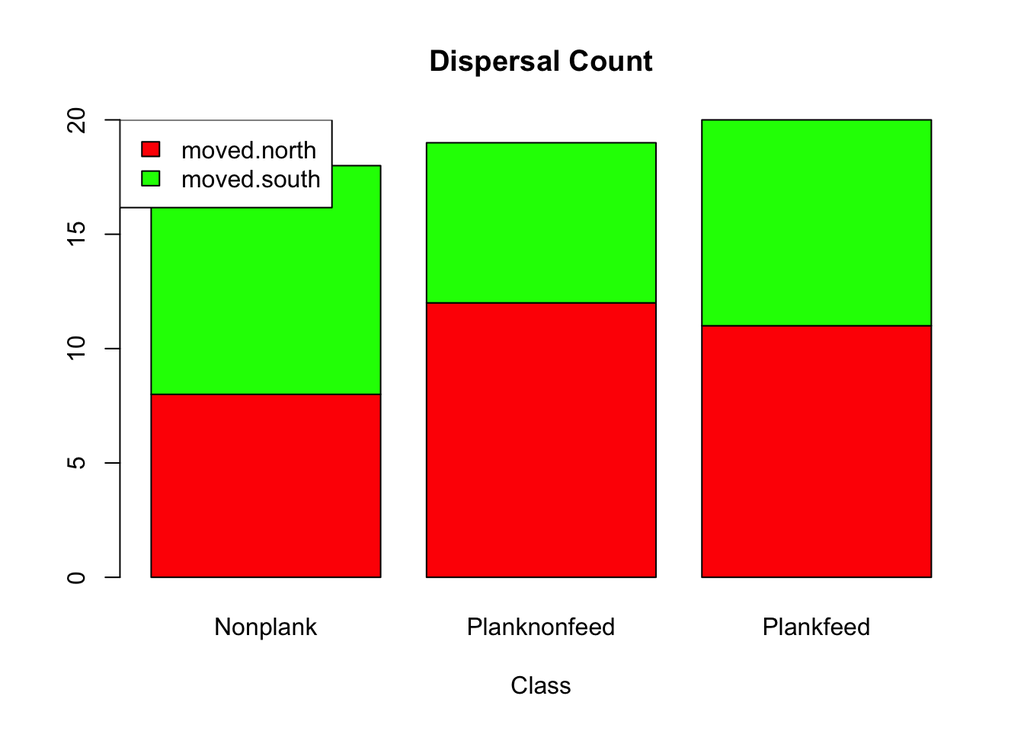

```r
barplot(count.disp,
main = "Dispersal Count",
xlab = "Class",
col = c("red","green")
)
legend("topleft",
c("moved.north","moved.south"),
fill = c("red","green")
)
```

It does not have strong evidence to show the association between dispersal and moved.north.

## 5

We can use one-way ANOVA to compare the means in groups to determine whether there is statistical evidence that the associated population means are different. So here we suspect that the dispersal is an important driver of moving north.

## 6

H0: The means are the same H1: Not H0 (At least one mean is different)

```r
disp.aov <- aov(moveDist ~ dispersal, data = disp)
summary(disp.aov)
```

```
##             Df Sum Sq Mean Sq F value Pr(>F)
## dispersal    2    4.9   2.446   0.176  0.839
## Residuals   54  749.1  13.871
```

We can see the p-value is 0.839, which we cannot reject the null hypothesis in any level of significance. We do not have enough evidence to show the difference in means as well as the association between moving north and dispersal.

## Problem 3

## 1

```r
d2
```

```
##    coast  migration
## 1   East  1.8361916
## 2   East  2.5652790
## 3   East  1.6479342
## 4   East  3.8357527
## 5   East  2.6965570
## 6   East  1.6615785
## 7   East  2.8386861
## 8   East  3.0644922
## 9   East  2.9182032
## 10  East  2.1251505
## 11  East  3.7606031
## 12  East  2.7508589
## 13  East  1.8408835
## 14  East  0.4067701
```

[output cut: 46 more lines]

```r
pace.east <- subset(d2, coast == "East")
pace.west <- subset(d2, coast == "West")
```

I think we can merely perform a one-sample t-test to determine if the mean migrating distances of east and west coast are different than 2.4, which is the climate condition.

## 2

H0: Mean migrating distance = 2.4 H1: Not H0 (for both east coast and west coast species)

## 3

```r
##East Coast
t.test(pace.east$migration, mu = 2.4, alternative = "two.sided")
```

```
##
##  One Sample t-test
##
## data:  pace.east$migration
## t = 0.48873, df = 29, p-value = 0.6287
## alternative hypothesis: true mean is not equal to 2.4
## 95 percent confidence interval:
##  2.163647 2.784778
## sample estimates:
## mean of x
##  2.474212
```

We can see the p-value is 0.62, which the null hypothesis cannot be rejected. We conclude that we do not have enough evidence to show there is difference between mean and 2.4.

```r
##West Coast
t.test(pace.west$migration, mu = 2.4, alternative = "two.sided")
```

```
##
##  One Sample t-test
##
## data:  pace.west$migration
## t = 2.1018, df = 29, p-value = 0.04437
## alternative hypothesis: true mean is not equal to 2.4
## 95 percent confidence interval:
##  2.423810 4.146282
## sample estimates:
## mean of x
##  3.285046
```

We can see the p-value is 0.04, which the null hypothesis can be rejected at 0.05 level. We conclude that we do have enough evidence to show there is difference between mean and 2.4 at 0.05 level.

## 4

```r
library(dplyr)
```

```r
library(ggplot2)
```

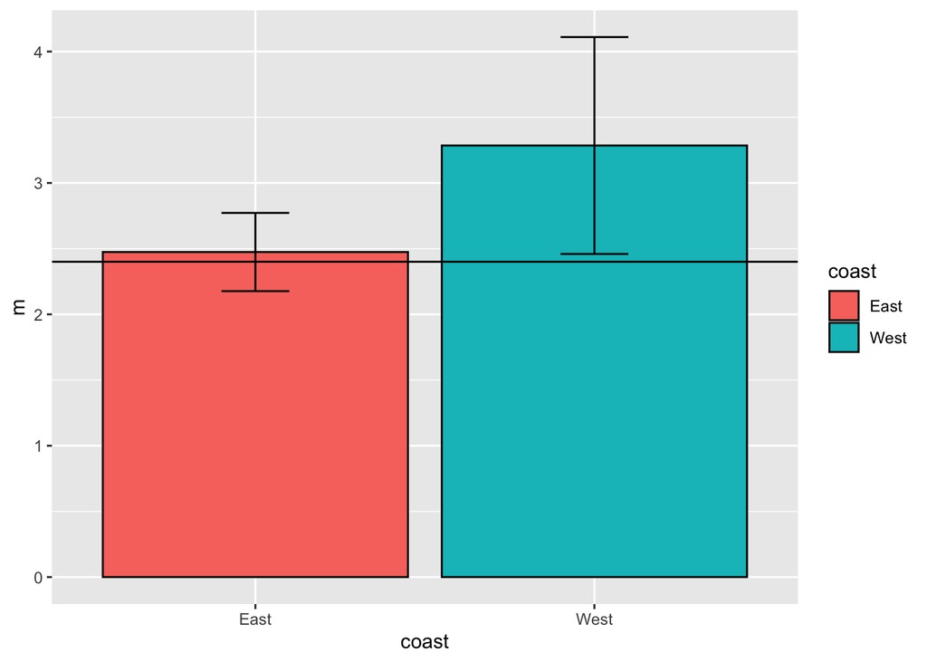

```r
## Group the d2 by coast categories and calculate the mean and se
ci.df <- d2 %>% group_by(coast) %>% summarise(m = mean(migration),
                                       stdv = sd(migration)/sqrt(length(migration)))



ggplot(ci.df, aes(coast,m,fill=coast)) +
  geom_bar(stat="identity", color="black",
           position=position_dodge()) +
  geom_hline(yintercept = 2.4) +
  geom_errorbar(aes(ymin=m-1.96*stdv, ymax=m+1.96*stdv), width=.2,
                position=position_dodge(.9))
```

From the plot, we can see the pace of climate is in the CI of east coast species’ migrating pace, but lower than the migrating pace of species from west coast. If we want to compare the rate of east and west coast communities, we have to eliminate the effect from the climate to make the experience variables under controlled.